# Homework #4: Boosting, Dimension reduction, Clustering

1. Load the iSPY1 dataset by running the following. Notice that there is a `fakeSite` column with values ranging from 1-8. We’ve added this column to simulate combining data from 8 different sites.

```r
ispy_dat <- fread("ispy1doctored_site.csv")
```

2. (1 point) Hold out sites 7 and 8 for testing. Store the training data in `datTrain` and the test data in `datTest`.

```r
# make HER2status a factor
ispy_dat$HR_HER2status <- factor(ispy_dat$HR_HER2status)

# split the data into train and test
datTest <- ispy_dat[fakeSite %in% c(7,8)]
datTrain <- ispy_dat[!fakeSite %in% c(7,8)]
```

3. (2 points) In this homework, we will manually implement site-wise 3-fold cross-validation (i.e. two sites per fold) rather than using the `caret` package. Create binary masks to split the rows in `datTrain` into 3 folds, where sites 1 and 2 are in the first fold, sites 3 and 4 are in the second fold, and sites 5 and 6 are in the third fold. Create a list with these three binary masks. It may be helpful to reference this list later in this homework.

```r
fold_list <- list(
    fold1 = datTrain$fakeSite %in% c(1,2),
    fold2 = datTrain$fakeSite %in% c(3,4),
    fold3 = datTrain$fakeSite %in% c(5,6)
)
```

## Boosting

4. Load the `gbm` package.

```r
library(gbm)
```

5. (3 points) We will select the hyperparameters for a gradient boosted model using site-wise three-fold CV. Create a function named `fit_fold` that takes as input the fold number `fold_idx`, number of trees, and interaction depth. The function will fit a gradient boosted model using `gbm` that predicts `MRI_LD_Tfinal` using all the predictors except for `fakeSite`. Train on all the folds except for the `fold_idx`-th one. The function should output the mean squared error of the fitted model on the held out fold. Use the folds you made in question 3. Fix the shrinkage hyperparameter in `gbm` as 0.01.

```r
fit_fold <- function(fold_idx, ntrees, depth){
    # split the training data into train/test for cross validation
    datTrain_forModel <- datTrain[!fold_list[[fold_idx]]]
    datTest_forModel <- datTrain[fold_list[[fold_idx]]]

    # fit the model using the training data
    gbm_model <- gbm(formula = MRI_LD_Tfinal ~ .-fakeSite,
                     data = datTrain_forModel,
                     n.trees = ntrees,
                     interaction.depth = depth,
                     shrinkage = 0.01,
                     n.minobsinnode = 10)

    # predict using the model on the test data
    predictions <- predict(gbm_model, newdata = datTest_forModel)

    # calculate and return the MSE
    MSE <- mean((datTest_forModel$MRI_LD_Tfinal - predictions)^2)
    return(MSE)
}
```

6. (4 points) Using the function you made in question 5, tune the number of trees and interaction depth using site-wise three-fold CV. Search over the values `n.trees=100, 200, 400, 800, 1600` and `interaction.depth=1, 2`. Which hyperparameter values minimize the cross-validated mean squared error?

```r
# create the tuning matrix
n_fold <- c(1, 2, 3)
n_trees <- c(100, 200, 400, 800, 1600)
interaction_depth <- c(1, 2)
tune.grid <- expand.grid(n_fold = n_fold,
                         ntrees = n_trees,
                         depth = interaction_depth)

# create a cross validate function
set.seed(7)
cross.validate <- function(parameters){
    fit_fold(parameters[1], parameters[2], parameters[3])
}
```

```r
# get all the MSEs
all_MSE <- apply(tune.grid, 1, cross.validate)
```

```r
# get the mean MSE for every 3 elements in the vector given structure of tune grid
cv_MSE <- sapply(seq(1,30,3), function(x){mean(all_MSE[x:(x+2)])})

# get which index has the lowest MSE
# multiply by three because cv_MSE is in groups of three
bestCV <- which.min(cv_MSE)*3
tune.grid[bestCV,2:3]
```

```
##   ntrees depth
## 9    400     1
```

```r
# confirm answer with `caret` package
fold_list_index <- list(fold1=which(!fold_list[[1]]),
                        fold2=which(!fold_list[[2]]),
                        fold3=which(!fold_list[[3]]))

tune.grid2 <- expand.grid(n.trees = n_trees,
                          interaction.depth = interaction_depth,
                          shrinkage = 0.01,
                          n.minobsinnode = 10)

fitControl <- trainControl(method = "cv", number = 3,
                           index = fold_list_index,
                           returnResamp = "all")
```

```r
set.seed(7)
gbm.cv3.byFold <- train(form = MRI_LD_Tfinal ~ .-fakeSite,
                        data = datTrain,
                        trControl = fitControl,
                        method = "gbm",
                        tuneGrid = tune.grid2)
```

```r
gbm.cv3.byFold$bestTune[,1:2]
```

```
##   n.trees interaction.depth
## 3     400                 1
```

7. (2 points) Plot the cross-validated error with respect to `n.trees`. Keep `interaction.depth` fixed at 1.

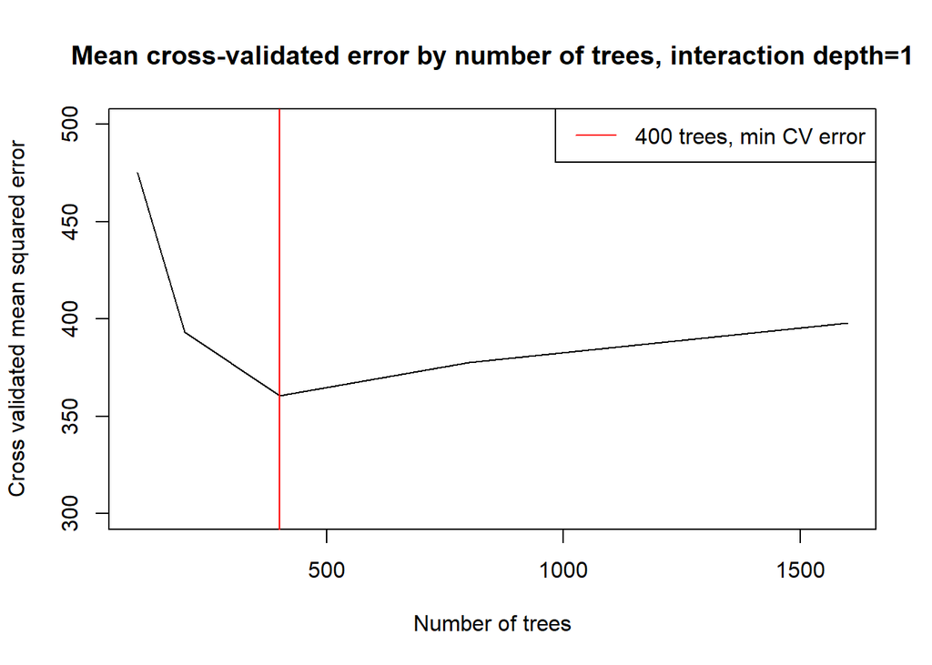

```r
plot(n_trees, cv_MSE[1:5], ylim=c(300,500), type = "l",
     main = "Mean cross-validated error by number of trees, interaction depth=1",
     ylab = "Cross validated mean squared error",
     xlab = "Number of trees")
abline(v=400, col="red")
legend(x="topright", legend = "400 trees, min CV error", lty=1, col = "red")
```

8. (1 point) Refit the gradient boosted model on all the training data (`datTrain`) using the hyperparameters that minimized the CV error.

```r
gbm.total <- gbm(formula = MRI_LD_Tfinal ~ .-fakeSite,
                 data = datTrain,
                 n.trees = 400,
                 interaction.depth = 1,
                 shrinkage = 0.01)
```

```
## Distribution not specified, assuming gaussian ...
```

9. (1 point) Evaluate the MSE of the fitted model on the test data.

```r
preds <- predict(gbm.total, datTest[,-c("fakeSite")])
```

```
## Using 400 trees...
```

```r
(MSE2 <- mean((datTest$MRI_LD_Tfinal - preds)^2))
```

```
## [1] 418.0419
```

## Kmeans

10. (1 point) Let’s perform kmeans on the iSPY data. Remove the columns “race”, “HR_HER2status”, and “fakeSite”. Call this new dataset `ispy_subdat`.

```r
ispy_subdat <- ispy_dat[,-c("race", "HR_HER2status", "fakeSite")]
```

11. (3 points) Tune the number of clusters used in K-means. To do this, use the function `fviz_nbclust` from the `factoextra` library. The function `fviz_nbclust` determines and visualizes the optimal number of clusters using different methods (within cluster sums of squares, average silhouette and gap statistics). Plot the average silhouette with respect to the number of clusters by passing in the argument `method="silhouette"`. What is the optimal number of clusters according to the silhouette statistic?

```r
# scale and center the data
scaled_ispy_subdat <- scale(ispy_subdat)

# load factoextra
library(factoextra)
```

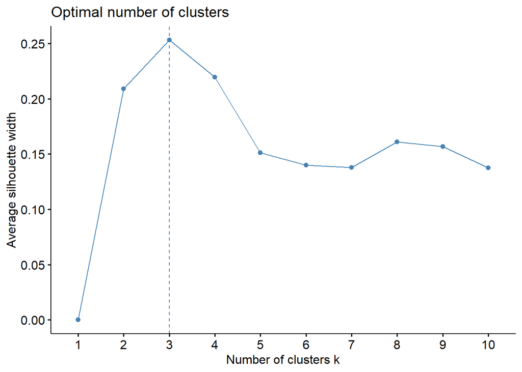

```r
# run fviz
fviz_nbclust(x=scaled_ispy_subdat,
             FUNcluster = kmeans,
             method = "silhouette")
```

The optimal number of clusters based on average silhouette width is 3.

12. (3 points) Refit k-means using the optimal number of clusters with 15 random initializations. Use the function `fviz_cluster()` to plot the clusters from K-means. Observations are represented by points in the plot, using principal components if $p > 2$. An ellipse is drawn around each cluster.

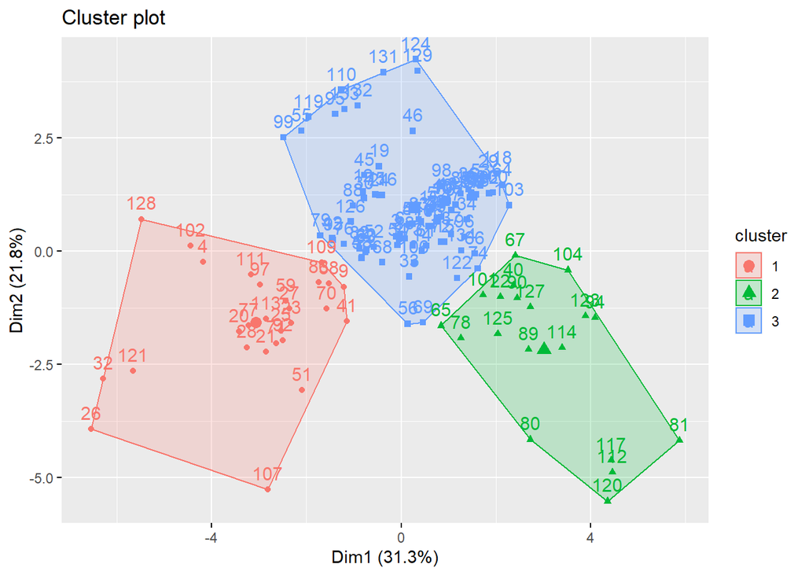

```r
fviz_cluster(
    kmeans(scaled_ispy_subdat, centers = 3, iter.max = 15),
    data = scaled_ispy_subdat
)
```